# Analyzing time and weather effects in NYC taxi demand

Ethan Yee

## Abstract

The current study examines time and weather effects in taxi ridership patterns across New York City in 2013, analyzing over 173 million taxi trips taken during the entire year. We examined hourly occupancy rates of taxis and used the corresponding hourly weather conditions we well as time factors as predictor variables for an OLS regression model search. It was shown that the presence of rain increases taxi ridership by about 5-10%, and the fact that it was raining was a more important predictor than the actual level of rain itself. Other factors such as temperature, humidity and windspeed showed no significant effect size on taxi ridership. We also examined the data using a visualization-based, non-OLS regression approach and found that there was a more significant micro-relationship, with taxi ridership increasing between 5.51AM-11.51AM on weekday mornings in the presence of rain.

## Introduction

The yellow taxi is a familiar and ubiquitous sight in New York City. For celebrities, tourists and locals alike, the taxi is one of the fastest and most convenient forms of non-public transport in a space-scarce city where street parking is hard to find.

The Taxi and Limousine Commission (TLC) of New York City regulates the 13,437 yellow taxis that ply the streets, and collects data for each pickup through the GPS units installed in NYC cabs. In 2014, open-data advocate Chris Whong successfully filed a Freedom of Information Law request for the data collected in 2013 (Whong, 2014), which has since been made publicly available. The data includes information such pickup and drop-off times and locations, number of passengers, trip time and distance, payment type as well as fare and tip amounts for each of the 173,179,759 rides taken in 2013.

Since the release of the data, numerous data scientists have conducted analyses of the various factors in the trip and fare data. However, most of this research is limited to analyses within the confines of this dataset, and there is surprisingly little material that cross-references other datasets.

The reseach presented here is thus an attempt to fill this gap in existing literature. While there are numerous studies on taxi policy issues and industry economics, there is considerably less attention paid to exogenous factors such as weather. Do people take more cabs when it is raining or snowing? What about on a hot summer day or a cold wintry night?

In the current study, hourly weather data from the National Oceanic and Atmosphere Administration (NOAA) will be used to determine if parameters such as temperature, rain, snow, and humidity have an effect on taxi ridership in NYC during the year of 2013. We will attempt to fit a model of weather and time effects on taxi ridership to determine the presence of any overall trends. Finally, we will also visualize the data with d3.js, a JavaScript library for data-driven visualizations, to allow for a more selective examination of any micro-trends.

## Literature Review

### Research on the same data

Following its release, the 2013 taxi trip and fare data has been analyzed in numerous different ways. For example, a quantitative analyst found that unsurprisingly, people who pay with credit cards tend to use the preset tip amounts (20%, 25%, 30%) shown on the screen (Wellington, 2015). However, he also found that certain cab companies calculate the default tip amounts based on the pre-tax total while others calculate the tip amount based on the post-tax total, and that the former was earning cab drivers about $200 more per year in extra tips.

The data has also been used to demonstrate current issues in data science. An internet security expert managed to de-anonymize the medallion IDs, allowing for potential de-identification of cab drivers(Pandurangan, 2014). [An intern at Neustar research also identified the home addressed of several potential strip club regulars by analyzing trips originating from a relatively isolated strip club between the hours of 12AM to 6AM (Tockar, 2014). However, his methods and results have also been disputed by others (Barth-Jones, 2014).

### Research of a similar scope

A 2014 paper by Princeton economist Henry Farber (2014) used similar trip data to analyze wage elasticities of NYC taxi drivers. Farber concluded that a) Instead of working more during profitable days, drivers were more likely to stop when they reached a daily income target, and b) Daily income targets of drivers were not fixed over the days of the week and varied rather significantly. As part of this research, Farber looked at the effect of rainfall on NYC taxi occupancy rates, and concluded that taxi occupancy rates increase by aproximately 4.8% in the rain while supply falls by 7.1%.

However, Farber’s research utilized a random sample of taxi trip sheets from 2009 to 2013 in his assessment, and focuses more on the economic effect of a single weather variable (rain) on the supply and demand of cabs. Our research will focus more on modelling taxi occupancy with the entire yearly dataset using numerous variables.

Yazici, Kamga & Singhal (2013) have also done similar research on the effect of weather on NYC taxis . However, their research was focused on analyzing taxi drivers’ decisionmaking process in making airport pickups, and as such the analysis is localized around airports in New York City and focuses on empty cruising time rather than taxi occupancy.

## Methods

### Processing the taxi data

The FOILed taxi data was obtained and examined. The fare data and trip data are tabulated separately in CSV format, and each dataset is further split up into 12 parts. The trip data which was used for this project totaled approximately 28.5GB.

Due to the size of the dataset, reading and processing the data with R’s standard `read.csv` command would require an inordinately large amount of time. As such, the `data.table` package was used for significantly decreased load times.

It was decided that instead of simply using the number of trips started per minute, we would calculate the per-minute occpuancy of taxis (as defined by the number of taxis with a paying fare on board) and use that as a measure of taxi demand. We felt that occupancy more accurately reflected the demand for taxis - at peak hours, it may be hard for potential customers to find a taxi because a large percentage of taxis are occupied. This woul be reflected in per-minute occupancy but not in the number of rides started. While there are a number of ways to calculate occupancy, the challenge was to do this in an efficient way due to the large amount of data we had.

We then determined that the most optimal way to calculate the occupancy at a certain minute would be to look at the total number of rides started from the first recorded minute in the dataset up to the current minute, and subtract the total number of rides ended form the first recorded minute in the dataset up to the previous minute. Calculating the cumulative sum of rides started/ended up to a certain point is easily done in statistical software like R, and is relatively fast compared to other methods (such as tallying the individual minutes which each of the 173 million rides take, and then tallying up the count).

Based on this approach, the relevant information required to calculate the per-minute occupancy (ie the starting and ending times for every single cab ride) was extracted and then aggregated by the minute, resulting in a count of the number of rides started and ended at every minute.

Using R’s cumulative sum function, we could then easily calculate the per-minute taxi occupancy using the approach described above.

Preliminary examination of the aggregated and summed data revealed that some cleaning was needed. In particular, the occupancy data for August 1/2/3/4/11 looked anomalous, as the occupancy data for each of these days was significantly lower than any other data point, and less than half the average occupancy over the entire year. A closer look at the original taxi dataset showed apparent anomalies in data collection during the 5 days, with a large number of trips that have a recorded distance of a few million miles.

An indicator variable was then created to reflect weekends and federal holidays since taxi usage patterns will presumably be different on these days. To achieve this, a Google search was conducted to determine a list of holidays in 2013.

### Processing the weather data

Weather data was sourced from NOAA’s Quality Controlled Local Climatological Data (National Climatic Data Center, 2015).

We first extracted the relevant hourly data from the QCLCD, including the weather type (whether there was rain or snow during that hour), temperature, humidity, windspeed and the hourly precipitation level. Each type of data also has an associated flag that records if the data is suspect. The relevant data was checked against the corresponding flags before being extracted.

The QCLCD includeed full weather measurements every hour on the 51st minute, but also takes measurements at other, non-regular intervals. Since the non-regular measurements do not contain the full set of data (for example, precipitation data is not included), only the full hourly observations were used for our purposes.

With the relevant data in hand, indicator variables were created for rain and snow. The QCLCD includes a `WeatherType` column that indicates the weather condition (ie rain, snow, etc) as well as the level (light, moderate or heavy). For example, a `+RA` in that column indicates heavy rain while a `-SN` indicates light snow. 6 indicator variables for light, moderate and heavy rain/snow were created, and the data further cleaned for later analysis.

### Merging the weather and taxi data

Since the weather data is recorded every hour on the 51st minute, the per-minute cab occupancy data was aggregated into hour-long blocks around the 51st minute, defining a block of time as starting at the 21st min and ending at the subsequent 20th min so the weather observation falls in the middle. The taxi and weather data was then merged.

### Regression-based analysis

We then conducted regression analysis on the merged dataset. OLS regression was used in an attempt to fit a model for the per-hourly taxi occupancy with regards to time effects (hour of the day, weekday/weekend) as well as numerous weather effects (rain, snow, wind, temperature, humidity).

Because it is well-known that taxi demand is time-dependent, we decided to construct a baseline model to explain the time effects. A simple scatterplot of occupancy against time was created to check for evidence of a long-term trend (ie taxi rides increasing or decreasing over the year). As the plot below shows, there does not appear to be any long-term trend. This allows us to simply use day of the week as a factor variable and disregard month/day.

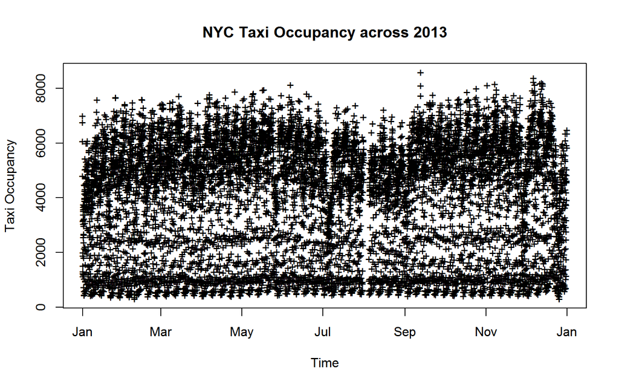

A simple regression of occupancy against hour of the day as a factor variable was thus constructed as a baseline. This model has an R^2 of .66 as well as large, significant coefficients for almost all of the hourly factors, which confirms the importance of time (specifically, hour of the day) as a predictor variable. More importantly, however, the model diagnostics show a somewhat increasing error variance. This is not surprising - at odd hours, there is a baseline ridership consisting of people who take cabs out of sheer necessity. Because of this, a semi-elastic log-transformed model was also considered for the baseline.

Comparing the log-transformed model and the untransformed model, we note that the error variances in both models are not entirely satisfactory. As the residual plots below show, the untransformed model (left) shows an increasing error variance at the lower 50 percentile and a somewhat constant error variance above the 50 percentile values. The log-transformed model (right) exhibits a somewhat constant error variance at the lower 50 percentile, correcting the issue with the previous model, but exhibits a decreasing error variance above the 70th percentile.

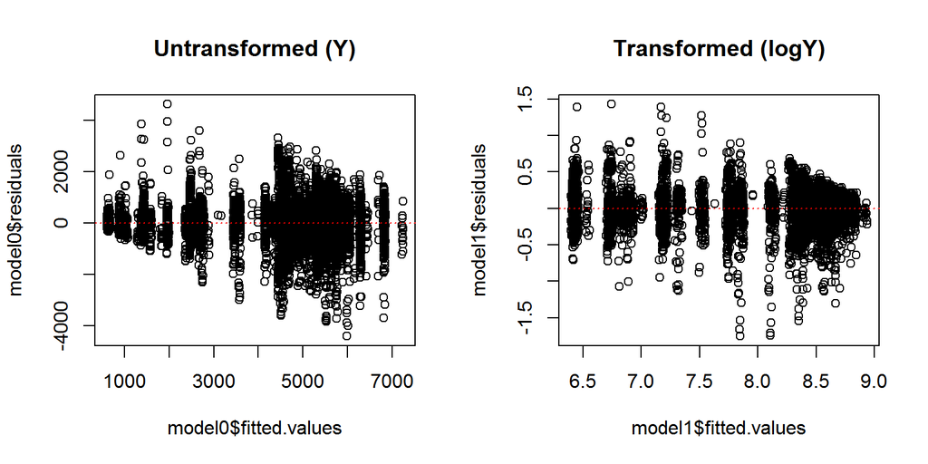

Because of this, we decided to use both baselines in our model search, and come up with the best explanatory model with both the transformed and untransformed scales. For both baselines, a model search was conducted with the rest of the time and weather variables using the Bayesian Information Criteria (BIC) as a measure of model suitability.

#### Best untransformed model

A selection of the best untransformed models obtained are shown below (f=factor variable):

```
##                                  Model Time.vars Weather.vars Rsquared    AIC      BIC
## 1            Hour(fr)*holWkend+Rain(f)        48            2   0.8411 140221.4 140581.6
## 2                Hour(f)*holWkend+Rain        48            1   0.8406 140250.2 140603.3
## 3    Hour(f)*holWkend+Rain(f)*holWkend        48            4   0.8416 140020.6 140394.9
## 4 Hour(f)*holWkend+Rain(f)+Temperature        48            2   0.8411 140221.4 140581.6
```

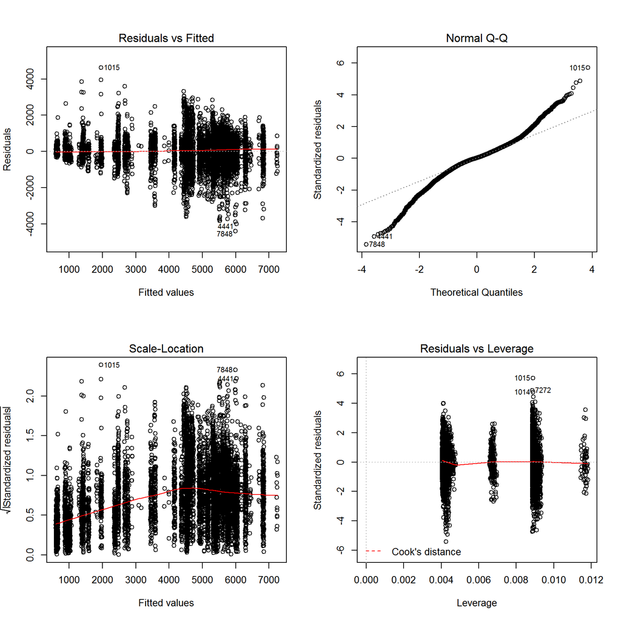

#### Best log-transformed model

A selection of the best log-transformed models obtained are shown below (f=factor variable):

```
##                               Model Time.vars Weather.vars Rsquared
## 1          Hour(f)*holWkend+Rain(f)        48            2   0.9009
## 2             Hour(f)*holWkend+Rain        48            1   0.9002
## 3 Hour(f)*holWkend+Rain(f)*holWkend        48            1   0.9005
##         AIC       BIC
## 1 -427.1347 -66.92759
## 2 -398.5004 -45.35616
## 3 -367.9367 -14.79246
```

Relevant diagnostic plots for the best log-transformed model (logY = Hour(f) * holWeekend + Rain(factor) ) are shown below.

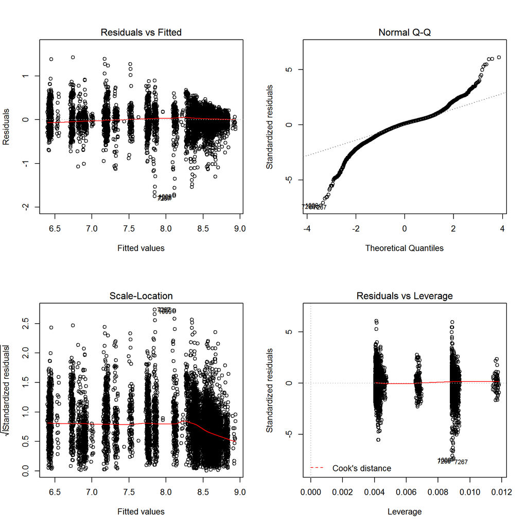

#### Analysis of best untransformed and best log-transformed model

As the 2 best models show, the fact that it was a weekend or federal holiday exhibited significant interaction effects with the hour of the day, suggesting that (unsurprisingly) hourly ridership patterns are different on weekdays and weekend/holidays. Temperature was slightly significant as a linear predictor, but ultimately did not contribute much to the goodness of fit and was discarded. Finally rain was also a significant predictor, although the presence of rain as a factor was more important than the actual precipitation level itself.

It should be noted that even though the R-squared for the best models were .90 and .84 for the log-transformed and untransformed models respectively, the time effects contributed much more to the fit than the weather effects. Even though the p-values for the coefficients for weather effects were significant, they increased the R-squared by less than .03.

Humidity and windspeed did not have significant predictive effects on cab ridership.

Based on the results of our regression analysis, we can state that much of the variability in taxi ridership in NYC could be attributed to time, and while weather has a significant impact on ridership the effect is relatively much smaller.

### Visualizing the data

We also proceeded with a second, visualization-based approach to see if we could capture any micro-trends that an OLS regression would not detect. For visualization purposes, the 6 indicator variables for light, moderate and heavy rain/snow were combined into one variable to be differentiated by color. “Heavy rain”" and “heavy snow”" was combined with “moderate rain” and “moderate snow” due to the very small number of observations, creating a factor variable with 5 conditions (0 for no rain/snow, 1 for light rain, 2 for moderate/heavy rain, 3 for light snow, 4 for moderate/heavy snow).

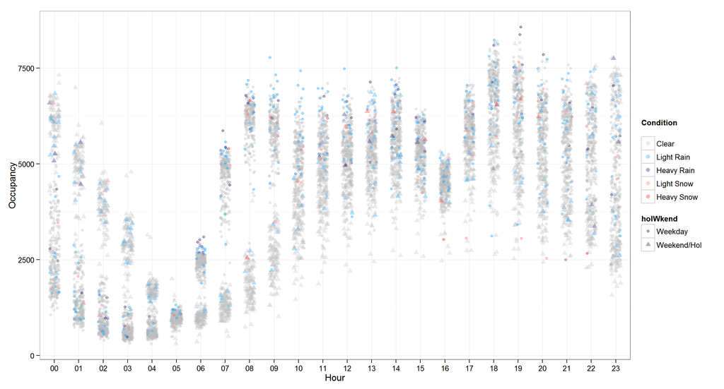

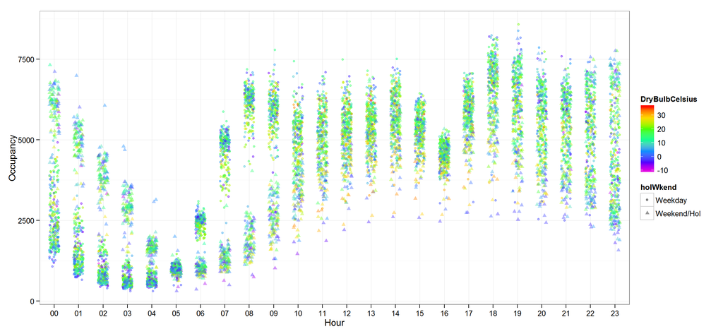

## Visualization-based Analysis

A cursory glance at the plots above suggests no significant effect of temperature or weather conditions on ridership. Closer inspection of the first plot, however, seems to hint at an hour-specific relationship of weather condition on ridership in the mornings, around 6.51AM and 7.51AM. In other words, it seems from the graph that taxi ridership increases when it is raining on a weekday morning.

To visualize the data more clearly, an interactive multi-factor scatterplot was made using the D3.js JavaScript library. The visualization takes the form of a multi-factor scatterplot showing time, occupancy, weather and a dummy variable indicating whether it is a weekday or a weekend. The visualization also allows the user to selective hide datapoints based on weather or type of day (weekday/weekend).

Besides the visualization, separate hourly boxplots for adverse weather (rain or snow) vs sunny weather was also created for each hour.

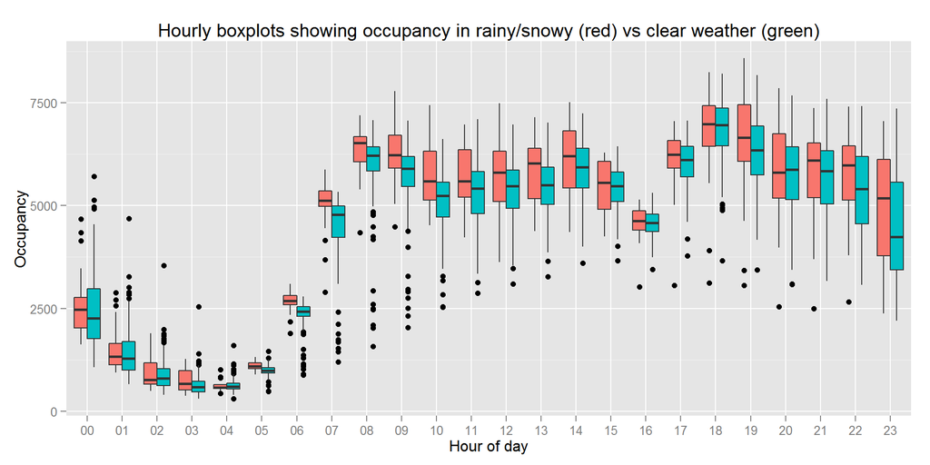

The boxplot and visualization appear to indicate numerous outliers on the low end. Further investigation reveals that most of these outliers occur on the following dates: July 5th, Nov 29th, and Dec 23rd-31st.

Looking back at the 2013 calendar reveals that July 4th lies on a Thursday. We postulate that the abnormally low ridership on July 5th is an effect of the special circumstances, since a large number of people travel on the July 4th weekend. This is borne out by the taxi ridership over the rest of the weekend, which is also abnormally low. The next outlier, Nov 29th, is Black Friday. Unfortunately without data from pervious years we are unable to determine causation or see if this is a historical pattern. Finally, the abnormally low ridership during the last 1.5 weeks of 2013 points to some sort of correlation with the holiday season.

In order to quantify if the rain had a statistically significant effect on taxi ridership for each hour, we conducted a statistical test for significant difference. As the hourly boxplot above shows, the per-hour taxi occupancy data is non-normal, with heavy tails and/or skewness apparent for a majority of the hours. Because of this, a Wilcoxon rank-sum test was used to compare the occupancy in the presence and absence of rain for each hour, since the Wilcoxon rank-sum test does not assume a normal distribution and is much more resistant to outliers, skewness and heavy tails.

The results of the rank-sum tests are shown below. 2 separate tests were conducted for each hour, one with all the data points and one with the potential outlying periods as defined above (July 5th, Nov 29th, Dec 23-31st) removed, to see if these data points had an undue effect on the result.

```
"Wilcoxon rank-sum tests for significant difference in taxi occupancy with/without rain"
## [1] "Hour"            "pvalue with all data" "pvalue without potential outliers"
## [1] "00"               "0.491393170351954"    "0.542035176455115"
## [1] "01"               "0.415841364450217"    "0.423106905609204"
## [1] "02"               "0.51895182529537"     "0.492469308156746"
## [1] "03"               "0.241434202418286"    "0.222788298154203"
## [1] "04"               "0.646177758911997"    "0.65305502499727"
## [1] "05"               "3.37743959592896e-05" "3.47239870721715e-05"
## [1] "06"               "8.0921040347276e-10"  "1.00920549849822e-10"
## [1] "07"               "1.82341303251507e-06" "4.63399087295844e-07"
## [1] "08"               "0.00255053758453608"  "0.00141600289686921"
## [1] "09"               "0.000416953560422241" "0.000186667555633533"
## [1] "10"               "0.000731389111826531" "0.000528478076002737"
## [1] "11"               "0.0156747041014134"   "0.0260918983620501"
## [1] "12"               "0.040214019184639"    "0.0292277413509032"
## [1] "13"               "0.0171190117966609"   "0.0263526340085878"
## [1] "14"               "0.0942360737515463"   "0.129237149723084"
## [1] "15"               "0.87131220072096"     "0.695476471589941"
## [1] "16"               "0.351419837586247"    "0.358607341521876"
## [1] "17"               "0.244277100438016"    "0.228443523156658"
## [1] "18"               "0.732521151859932"    "0.964302259268905"
## [1] "19"               "0.0868722181977562"   "0.0579637869400686"
## [1] "20"               "0.582719135931902"    "0.482922775371696"
## [1] "21"               "0.327670051694012"    "0.236237049198895"
## [1] "22"               "0.0879396592171397"   "0.119235986595987"
## [1] "23"               "0.0774448264992482"   "0.0994127527964246"
```

## Discussion

While there have been numerous studies done on the NYC taxi data, and some studies relating weather to taxi ridership, we decided to focus our efforts solely on examining the effects of weather and time on taxi ridership using the full data, and attempt to create an explanatory model with these variables.

The results of this study show that the hour of the day has a very significant effect on taxi ridership, and this effect changes on weekends and holidays. Temperature and the presence of rain were both found to affect ridership in a significant way, but the effect size is small that temperature was ultimately removed during the model search. Presence of rain also improved the model only marginally, suggesting more localized effects. The visualization-based analysis bore this out, showing that taxi occupancy is higher in the presence of rain on a weekday morning from 5.51AM to 11.51AM.

It is not unreasonable to postulate that this relationship is related to the morning commute, and it is likely that on rainy days people are more inclined to take a taxi to work for various reasons. Of course, this effect size is much smaller compared to the effects of time.

Why was the presence of rain more important than the actual precipitation level? We postulate that the onset of rain creates a significant inconvenience, and the increased inconvenience of heavy rain over light rain is relatively small. When it starts to rain (with an hourly precipitaion level of >.1 inches), people have to use umbrellas and will get wet. The people willing and able to switch to taxi as a mode of transportation over the subway/bus do so because it is raining, not because the rain is getting heavy.

Demand forecasting for taxis has implications on many different areas, be it commercial or governmental. This study has demonstrated that weather should be considered as a factor influencing taxi ridership.

Of course, this analysis only touches the surface of what is possible in this area. While our model accurately describes taxi ridership over the span of the dataset, actual time series models will be needed to forecast demand. The location data included in the taxi trip data is also a treasure trove of information that could also be used in furthering this analysis to great effect, either in improving the model or in determining micro-effects of rain (perhaps some neighborhoods are more willing to splurge on a cab during the rain).

## Conclusion

Using hourly weather data from NOAA and taxi trip data released by the NYC TLC, we examined the relationship between average hourly taxi occupancy and weather/time variables. By using an OLS model search with BIC and R-squared as the main criteria, we find that hour of the day is highly significant in predicting cab occupancy, and this relationship is different on weekend and federal holidays. Of the weather parameters we analyzed, only temperature and the presence of rain appear to be significant, although the addition of weather parameters only improved the model marginally. Because the small improvement of fit suggests that there are more localized trends, we also used a visualization-based approach to analyze the data, and found that rain was a highly significant variable in causing increased cab occupancy between the hours of 5.51AM and 11.51AM on weekday mornings.

## References

Whong, C. (2014, March 18). FOILing NYC’s Taxi Trip Data. Retrieved May 6, 2015, from http://chriswhong.com/open-data/foil_nyc_taxi/

Wellington, B. (2015, January 5). How Software in Half of NYC Cabs Generates $5.2 Million a Year in Extra Tips. Retrieved May 6, 2015, from http://iquantny.tumblr.com/post/107245431809/how-software-in-half-of-nyc-cabs-generates-5-2

Pandurangan, V. (2014, June 21). On Taxis and Rainbows. Retrieved May 6, 2015, from https://medium.com/@vijayp/of-taxis-and-rainbows-f6bc289679a1

Tockar, A. (2014, September 15). Riding with the Stars: Passenger Privacy in the NYC Taxicab Dataset. Retrieved May 6, 2015, from http://research.neustar.biz/2014/09/15/riding-with-the-stars-passenger-privacy-in-the-nyc-taxicab-dataset/

Barth-Jones, D. (2014, November 21). The Antidote for “Anecdata”: A Little Science Can Separate Data Privacy Facts from Folklore. Retrieved May 6, 2015, from http://blogs.law.harvard.edu/infolaw/2014/11/21/the-antidote-for-anecdata-a-little-science-can-separate-data-privacy-facts-from-folklore/

Farber, H. S. (2014). Why You Can’t Find a Taxi in the Rain and Other Labor Supply Lessons from Cab Drivers. National Bureau of Economic Research Working Paper, No. 20604.

Yazici, M. A., Kamga, C., & Singhal, A. (2013, 6-9 Oct). A big data driven model for taxi drivers’ airport pick-up decisions in New York City. *2013 IEEE International Conference on Big Data*. p37-44. doi:10.1109/BigData.2013.6691775

National Climatic Data Center. (n.d.). Quality Controlled Local Climatological Data (QCLCD). Retrieved February 15, 2015, from http://www.ncdc.noaa.gov/data-access/land-based-station-data/land-based-datasets/quality-controlled-local-climatological-data-qclcd